# Direct, total and separable effects, using inverse probability weighting (IPW)

*Note:* Most of the code in this tutorial is written in R base, to mimic the original code from the published papers (see *References*). Dr. Elena Dudukina has a version of this code in R tidyverse [here](https://www.elenadudukina.com/post/competing-events/2022-11-24-competing-events/).

## Conditional pooled logistic models

- First, we run a set of conditional pooled logistic models, both as a first step to calculate the risk of prostate cancer death, and to calculate weights for death due to other causes, and weights for censoring due to loss to follow-up

```r
### Pooled logistic regression for prostate cancer death (this will be needed in the next section)
plrFitP <-
  glm(
    prostateDeath ~ rx * (dtime + I(dtime ^ 2) + I(dtime ^ 3)) + normalAct + ageCat + hx + hgBinary ,
    data = longProstRed,
    family = binomial())

### Pooled logistic regression for death due to other causes

plrFitO <-
  glm(
    otherDeath ~ dtime + I(dtime ^ 2) + normalAct + ageCat + hx + hgBinary + rx ,
    data = longProstRed,
    family = binomial())


### Pooled logistic regression for censoring after time 50

temp50 <- longProstRed[longProstRed$dtime > 50,]

plrFitC <-
  glm(eventCens ~  normalAct + ageCat + hx + rx,
      data = temp50,
      family = binomial())
```

- Fit models for the numerators in the stabilized weights corresponding to death due to other causes, and for censoring

```r
plrFitCnum <-
  glm(eventCens ~ rx , data = temp50, family = binomial())

plrFitOnum <-
  glm(otherDeath ~ dtime + I(dtime ^ 2) + rx,
      data = longProstRed,
      family = binomial())
```

## Weights calculation

### Calculate weights for censoring due to loss to follow-up

```r
### Denominator

longProstRed$predC <-
  rep(1, dim(longProstRed)[1]) # The probability of *not* being censored is 1 for all t <= 50

longProstRed$predC[longProstRed$dtime > 50] <- # update this probability from time 50 and onwards
  1 - predict(plrFitC, newdata = temp50, type = 'response')

### Numerator

longProstRed$predCnum <-
  rep(1, dim(longProstRed)[1])

longProstRed$predCnum [longProstRed$dtime > 50] <-
  1 - predict(plrFitCnum, newdata = temp50, type = 'response')

predC <- longProstRed$predC

predCnum <- longProstRed$predCnum
```

- Glimpse of data:

| patno | dtime | predC | predCnum |
| --- | --- | --- | --- |
| 8 | 44 | 1.000000 | 1.0000000 |
| 8 | 45 | 1.000000 | 1.0000000 |
| 8 | 46 | 1.000000 | 1.0000000 |
| 8 | 47 | 1.000000 | 1.0000000 |
| 8 | 48 | 1.000000 | 1.0000000 |
| 8 | 49 | 1.000000 | 1.0000000 |
| 8 | 50 | 1.000000 | 1.0000000 |
| 8 | 51 | 0.963553 | 0.9693252 |
| 8 | 52 | 0.963553 | 0.9693252 |
| 8 | 53 | 0.963553 | 0.9693252 |
| 8 | 54 | 0.963553 | 0.9693252 |
| 8 | 55 | 0.963553 | 0.9693252 |
| 8 | 56 | 0.963553 | 0.9693252 |
| 8 | 57 | 0.963553 | 0.9693252 |
| 8 | 58 | 0.963553 | 0.9693252 |
| 8 | 59 | 0.963553 | 0.9693252 |

- Calculate the cumulative probability over time:

```r
cumPredC <-
  unlist(aggregate(predC ~ longProstRed$patno, FUN = cumprod)$predC,
         use.names = F)

cumPredCnum <-
  unlist(aggregate(predCnum ~ longProstRed$patno, FUN = cumprod)$predC,
         use.names = F)
```

- Glimpse of data:

| patno | dtime | predC | predCnum | cumPredC |
| --- | --- | --- | --- | --- |
| 8 | 44 | 1.000000 | 1.0000000 | 1.0000000 |
| 8 | 45 | 1.000000 | 1.0000000 | 1.0000000 |
| 8 | 46 | 1.000000 | 1.0000000 | 1.0000000 |
| 8 | 47 | 1.000000 | 1.0000000 | 1.0000000 |
| 8 | 48 | 1.000000 | 1.0000000 | 1.0000000 |
| 8 | 49 | 1.000000 | 1.0000000 | 1.0000000 |
| 8 | 50 | 1.000000 | 1.0000000 | 1.0000000 |
| 8 | 51 | 0.963553 | 0.9693252 | 0.9635530 |
| 8 | 52 | 0.963553 | 0.9693252 | 0.9284343 |
| 8 | 53 | 0.963553 | 0.9693252 | 0.8945956 |
| 8 | 54 | 0.963553 | 0.9693252 | 0.8619902 |
| 8 | 55 | 0.963553 | 0.9693252 | 0.8305733 |
| 8 | 56 | 0.963553 | 0.9693252 | 0.8003013 |
| 8 | 57 | 0.963553 | 0.9693252 | 0.7711327 |
| 8 | 58 | 0.963553 | 0.9693252 | 0.7430272 |
| 8 | 59 | 0.963553 | 0.9693252 | 0.7159460 |

- Calculate unstabilized and stabilized weights

```r
### Unstabilized weights
weights_cens <- 1 / cumPredC

### Stabilized weights

weights_cens_stab <- cumPredCnum / cumPredC
```

| patno | dtime | predC | predCnum | cumPredC | weights_cens | weights_cens_stab |
| --- | --- | --- | --- | --- | --- | --- |
| 8 | 44 | 1.000000 | 1.0000000 | 1.0000000 | 1.000000 | 1.000000 |
| 8 | 45 | 1.000000 | 1.0000000 | 1.0000000 | 1.000000 | 1.000000 |
| 8 | 46 | 1.000000 | 1.0000000 | 1.0000000 | 1.000000 | 1.000000 |
| 8 | 47 | 1.000000 | 1.0000000 | 1.0000000 | 1.000000 | 1.000000 |
| 8 | 48 | 1.000000 | 1.0000000 | 1.0000000 | 1.000000 | 1.000000 |
| 8 | 49 | 1.000000 | 1.0000000 | 1.0000000 | 1.000000 | 1.000000 |
| 8 | 50 | 1.000000 | 1.0000000 | 1.0000000 | 1.000000 | 1.000000 |
| 8 | 51 | 0.963553 | 0.9693252 | 0.9635530 | 1.037826 | 1.005991 |
| 8 | 52 | 0.963553 | 0.9693252 | 0.9284343 | 1.077082 | 1.012017 |
| 8 | 53 | 0.963553 | 0.9693252 | 0.8945956 | 1.117824 | 1.018080 |
| 8 | 54 | 0.963553 | 0.9693252 | 0.8619902 | 1.160106 | 1.024178 |
| 8 | 55 | 0.963553 | 0.9693252 | 0.8305733 | 1.203988 | 1.030314 |
| 8 | 56 | 0.963553 | 0.9693252 | 0.8003013 | 1.249529 | 1.036486 |
| 8 | 57 | 0.963553 | 0.9693252 | 0.7711327 | 1.296794 | 1.042695 |
| 8 | 58 | 0.963553 | 0.9693252 | 0.7430272 | 1.345846 | 1.048941 |
| 8 | 59 | 0.963553 | 0.9693252 | 0.7159460 | 1.396753 | 1.055225 |

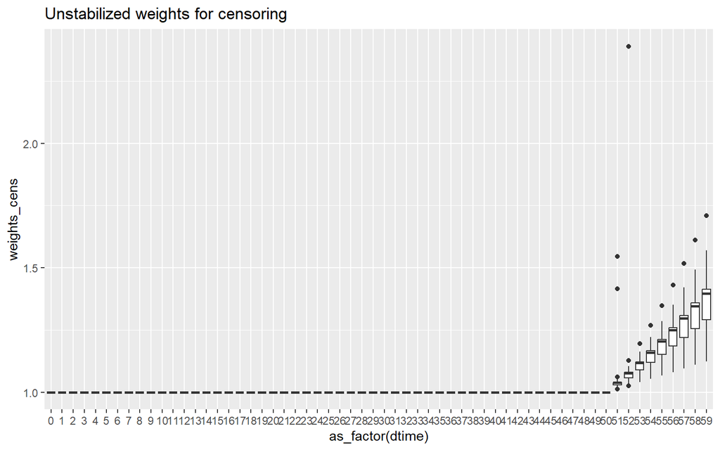

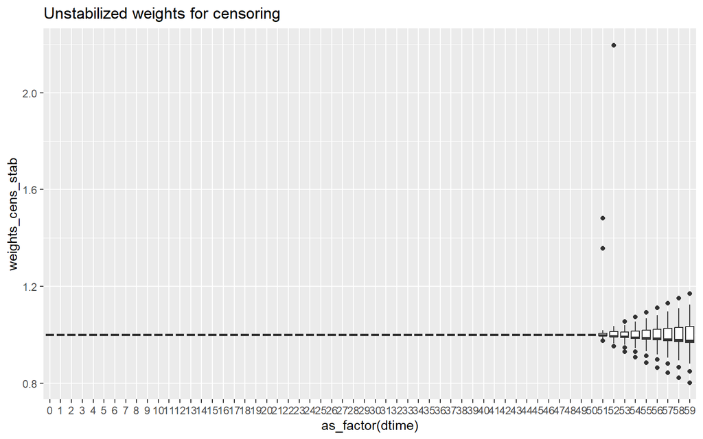

### Calculate unstabilized and stabilized weights for death from other causes

```r
### Denominator

predO <-
  1 - predict(plrFitO, newdata = longProstRed, type = 'response')

### Numerator
predOnum <-
  1 - predict(plrFitOnum, newdata = longProstRed, type = 'response')

### Calculate cumulative probability

cumPredO <-
  unlist(aggregate(predO ~ longProstRed$patno, FUN = cumprod)$predO,
         use.names = F)

cumPredOnum <-
  unlist(aggregate(predOnum ~ longProstRed$patno, FUN = cumprod)$predO,
         use.names = F)

### Weight calculation

weights_compev <- 1 / cumPredO

weights_compev_stab <-
  cumPredOnum / cumPredO
```

- Glimpse of data

| patno | dtime | cumPredO | cumPredOnum | weights_compev | weights_compev_stab |
| --- | --- | --- | --- | --- | --- |
| 487 | 0 | 0.9892248 | 0.9816935 | 1.010893 | 0.9923866 |
| 487 | 1 | 0.9787493 | 0.9641208 | 1.021712 | 0.9850538 |
| 487 | 2 | 0.9685558 | 0.9472325 | 1.032465 | 0.9779844 |
| 487 | 3 | 0.9586275 | 0.9309829 | 1.043158 | 0.9711624 |
| 487 | 4 | 0.9489487 | 0.9153301 | 1.053798 | 0.9645728 |
| 487 | 5 | 0.9395048 | 0.9002352 | 1.064391 | 0.9582018 |
| 487 | 6 | 0.9302818 | 0.8856621 | 1.074943 | 0.9520364 |
| 487 | 7 | 0.9212666 | 0.8715776 | 1.085462 | 0.9460645 |

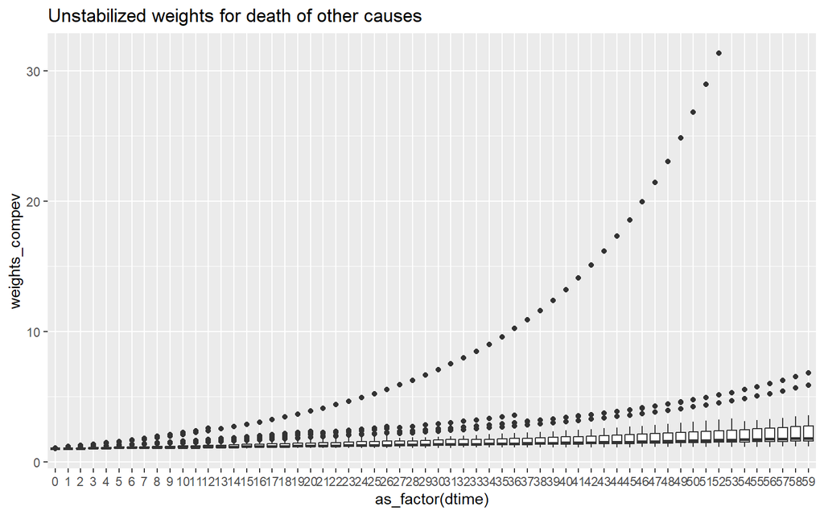

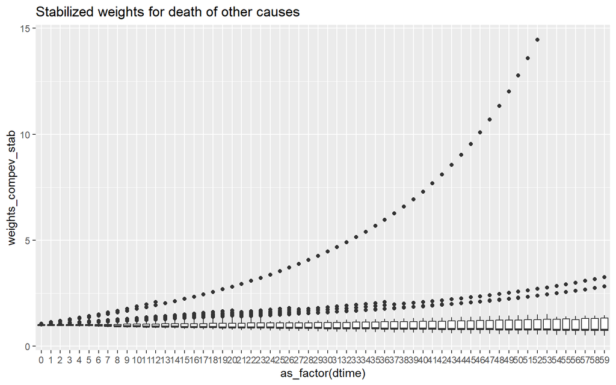

- Multiply weights for censoring and for death due to other causes

```r
weights_de <- weights_cens * weights_compev

weights_de_stab <- weights_cens_stab * weights_compev_stab
```

- Assess weights

```r
summary(weights_de)
```

```
##    Min. 1st Qu.  Median    Mean 3rd Qu.    Max.
##   1.003   1.112   1.266   1.484   1.542  74.950
```

```r
summary(weights_de_stab)
```

```
##    Min. 1st Qu.  Median    Mean 3rd Qu.    Max.
##  0.4028  0.8615  0.9733  1.0156  1.0681 31.7854
```

## Direct effect estimation

In this section and the following ones, we will apply the `nonParametricCumHaz` and `nonParametricCumInc` functions from the `utility_functions` script available in this repository. These functions are necessary to calculate hazards and cumulative incidence. [Link](https://github.com/palolili23/SER_competing_events_workshop/blob/main/R/utility_functions.R)

The functions look like this:

```r
nonParametricCumHaz <-
  function(weightVector,
           inputdata,
           grp,
           outcomeProstate = TRUE) {
    outputHazards <- rep(NA, length.out = length(cutTimes))
    counter <- 1
    for (i in cutTimes) {
      if (outcomeProstate) {
        indices <-
          inputdata$dtime == i &
          inputdata$rx == grp &
          inputdata$eventCens == 0 & inputdata$otherDeath == 0
        eventIndicator <- indices & inputdata$prostateDeath == 1
      } else{
        indices <-
          inputdata$dtime == i & inputdata$rx == grp & inputdata$eventCens == 0
        eventIndicator <- indices & inputdata$otherDeath == 1
      }
      outputHazards[counter] <-
        sum(weightVector[eventIndicator]) / sum(weightVector[indices])
      counter <- counter + 1
    }
    return(outputHazards)
  }

nonParametricCumInc <- function(hazard1, hazard2, competing = FALSE) {
  inc <- rep(NA, length.out = length(cutTimes))
  cumulativeSurvival <- c(1, cumprod((1 - hazard1) * (1 - hazard2)))
  counter <- 1
  for (i in 1:length(cutTimes)) {
    if (!competing) {
      inc[i] <- hazard1[i] * (1 - hazard2[i]) * cumulativeSurvival[i]
    } else{
      inc[i] <- hazard1[i] * cumulativeSurvival[i]
    }
  }
  cumInc <- cumsum(inc)
  return(cumInc)
}
```

Following equation (37) from [Young et al. Statistics in Medicine. 2020](https://onlinelibrary.wiley.com/doi/abs/10.1002/sim.8471).

```r
### Calculate cumulative hazards and cumulative incidence for the treated arm

#### Unstabilized
Treated_de_hazardP <-
  nonParametricCumHaz(
    weights_de,
    inputdata = longProstRed,
    grp = 1,
    outcomeProstate = TRUE)

Treated_de_hazardO <- rep(0, length.out = (length(cutTimes)))

cumIncTreated_de <-
  nonParametricCumInc(Treated_de_hazardP, Treated_de_hazardO)

#### Stabilized
Treated_de_hazardPs <-
  nonParametricCumHaz(
    weights_de_stab,
    inputdata = longProstRed,
    grp = 1,
    outcomeProstate = TRUE)

Treated_de_hazardOs <- rep(0, length.out = (length(cutTimes)))

cumIncTreated_des <-
  nonParametricCumInc(Treated_de_hazardPs, Treated_de_hazardOs)

### Calculate cumulative hazards and cumulative incidence for the placebo arm

#### Unstabilized

Placebo_de_hazardP <-
  nonParametricCumHaz(
    weights_de,
    inputdata = longProstRed,
    grp = 0,
    outcomeProstate = TRUE
  )

Placebo_de_hazardO <- rep(0, length.out = (length(cutTimes)))

cumIncPlacebo_de <-
  nonParametricCumInc(Placebo_de_hazardP, Placebo_de_hazardO)

#### Stabilized

Placebo_de_hazardPs <-
  nonParametricCumHaz(
    weights_de_stab,
    inputdata = longProstRed,
    grp = 0,
    outcomeProstate = TRUE
  )

Placebo_de_hazardOs <- rep(0, length.out = (length(cutTimes)))

cumIncPlacebo_des <-
  nonParametricCumInc(Placebo_de_hazardPs, Placebo_de_hazardOs)
```

- Risks under each treatment arm at 60 months of follow-up, risk difference and risk ratio

```r
## Unstabilized
cumIncTreated_de_60 <- cumIncTreated_de[length(cutTimes)]

cumIncPlacebo_de_60 <- cumIncPlacebo_de[length(cutTimes)]

de_rr <- cumIncTreated_de_60 / cumIncPlacebo_de_60

de_rd <- cumIncTreated_de_60 - cumIncPlacebo_de_60

results_de <- data.frame(cumIncTreated_de_60, cumIncPlacebo_de_60, de_rr, de_rd)

knitr::kable(round(results_de, 2))
```

| cumIncTreated_de_60 | cumIncPlacebo_de_60 | de_rr | de_rd |
| --- | --- | --- | --- |
| 0.36 | 0.37 | 0.97 | -0.01 |

```r
## Stabilized

cumIncTreated_des_60 <- cumIncTreated_des[length(cutTimes)]

cumIncPlacebo_des_60 <- cumIncPlacebo_des[length(cutTimes)]

des_rr <- cumIncTreated_des_60 / cumIncPlacebo_des_60

des_rd <- cumIncTreated_des_60 - cumIncPlacebo_des_60

results_des <- data.frame(cumIncTreated_des_60, cumIncPlacebo_des_60, des_rr, des_rd)

knitr::kable(round(results_des, 2))
```

| cumIncTreated_des_60 | cumIncPlacebo_des_60 | des_rr | des_rd |
| --- | --- | --- | --- |
| 0.36 | 0.37 | 0.97 | -0.01 |

- Cumulative incidence curves

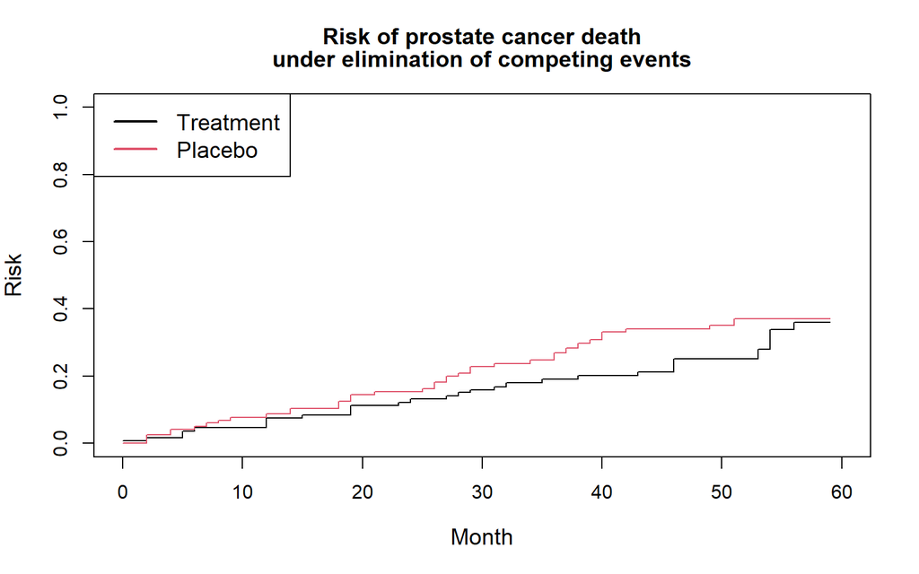

```r
plot(
  cutTimes, cumIncTreated_de, type = "s",
  ylim = c(0, 1), ylab = "Risk", xlab = "Month",
  lty = 1, lwd = 1, xlim = c(0, 60),
  cex.lab = 1.2, cex.main = 1.2,
  main = c(
    paste("Risk of prostate cancer death"),
    paste("under elimination of competing events")
  )
)
lines(
  cutTimes,
  cumIncPlacebo_de,
  type = "s", col = 2, ylim = c(0, 1), lwd = 1)

legend(
  "topleft", c("Treatment", "Placebo"),
  col = c(1, 2, 1, 2),
  lty = c(1, 1, 2, 2),
  cex = 1.2, pt.cex = 1.2, lwd = 2)
```

## Total effect estimation.

For this effect, we will only use the unstabilized weights we calculated for censoring due to loss to follow-up `weights_cens`, but using `weights_cens_stab` is possible as well.

Following equation (40) from [Young et al. Statistics in Medicine. 2020](https://onlinelibrary.wiley.com/doi/abs/10.1002/sim.8471).

```r
### Calculate hazards and cumulative incidence for the treated arm

Treated_te_hazardP <-
  nonParametricCumHaz(
    weights_cens,
    inputdata = longProstRed,
    grp = 1,
    outcomeProstate = TRUE)

Treated_te_hazardO <-
  nonParametricCumHaz(
    weights_cens,
    inputdata = longProstRed,
    grp = 1,
    outcomeProstate = FALSE)

cumIncTreated_te <-
  nonParametricCumInc(Treated_te_hazardP, Treated_te_hazardO)

### Calculate cumulative hazards and cumulative incidence for the placebo arm

Placebo_te_hazardP <-
  nonParametricCumHaz(
    weights_cens,
    inputdata = longProstRed,
    grp = 0,
    outcomeProstate = TRUE)

Placebo_te_hazardO <-
  nonParametricCumHaz(
    weights_cens,
    inputdata = longProstRed,
    grp = 0,
    outcomeProstate = FALSE)

cumIncPlacebo_te <-
  nonParametricCumInc(Placebo_te_hazardP, Placebo_te_hazardO)
```

- Risks under each treatment arm at 60 months of follow-up, risk difference and risk ratio

```r
cumIncTreated_te_60 <- cumIncTreated_te[length(cutTimes)]

cumIncPlacebo_te_60 <- cumIncPlacebo_te[length(cutTimes)]

te_rr <- cumIncTreated_te_60 / cumIncPlacebo_te_60

te_rd <- cumIncTreated_te_60 - cumIncPlacebo_te_60

results_te <- data.frame(cumIncTreated_te_60, cumIncPlacebo_te_60, te_rr, te_rd)

knitr::kable(round(results_te, 2))
```

| cumIncTreated_te_60 | cumIncPlacebo_te_60 | te_rr | te_rd |
| --- | --- | --- | --- |
| 0.22 | 0.28 | 0.78 | -0.06 |

- Cumulative incidence curves

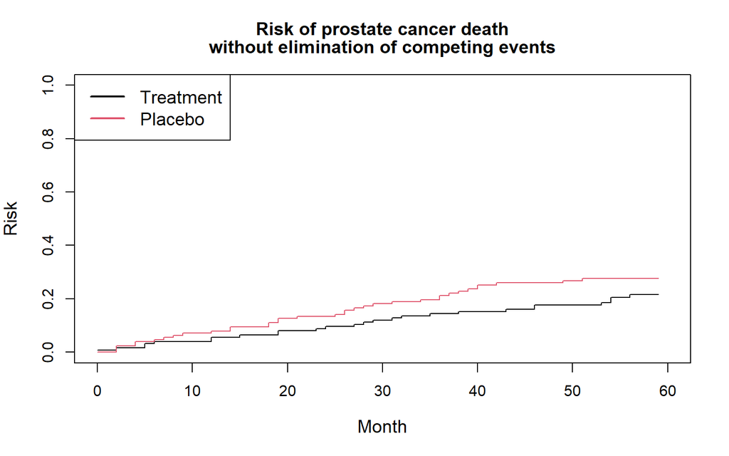

```r
plot(
  cutTimes, cumIncTreated_te, type = "s",
  ylim = c(0, 1), ylab = "Risk", xlab = "Month",
  lty = 1, lwd = 1, xlim = c(0, 60),
  cex.lab = 1.2, cex.main = 1.2,
  main = c(
    paste("Risk of prostate cancer death"),
    paste("without elimination of competing events")
  )
)
lines(
  cutTimes,
  cumIncPlacebo_te,
  type = "s", col = 2, ylim = c(0, 1), lwd = 1)

legend(
  "topleft", c("Treatment", "Placebo"),
  col = c(1, 2, 1, 2), lty = c(1, 1, 2, 2),
  cex = 1.2, pt.cex = 1.2, lwd = 2)
```

## Total effect on death for other causes

We will use the hazards obtained for the total effect, from the previous section.

```r
cumIncTreated_te_comp <-
  nonParametricCumInc(Treated_te_hazardO, Treated_te_hazardP, competing = TRUE)

cumIncPlacebo_te_comp <-
  nonParametricCumInc(Placebo_te_hazardO, Placebo_te_hazardP, competing = TRUE)
```

- Risks under each treatment arm at 60 months of follow-up, risk difference and risk ratio

```r
cumIncTreated_te_comp_60 <- cumIncTreated_te_comp[length(cutTimes)]

cumIncPlacebo_te_comp_60 <- cumIncPlacebo_te_comp[length(cutTimes)]

te_comp_rr <- cumIncTreated_te_comp_60 / cumIncPlacebo_te_comp_60

te_comp_rd <- cumIncTreated_te_comp_60 - cumIncPlacebo_te_comp_60

results_te_comp <- data.frame(cumIncTreated_te_comp_60, cumIncPlacebo_te_comp_60, te_comp_rr, te_comp_rd)

knitr::kable(round(results_te_comp, 2))
```

| cumIncTreated_te_comp_60 | cumIncPlacebo_te_comp_60 | te_comp_rr | te_comp_rd |
| --- | --- | --- | --- |
| 0.51 | 0.43 | 1.19 | 0.08 |

- Cumulative incidence curves

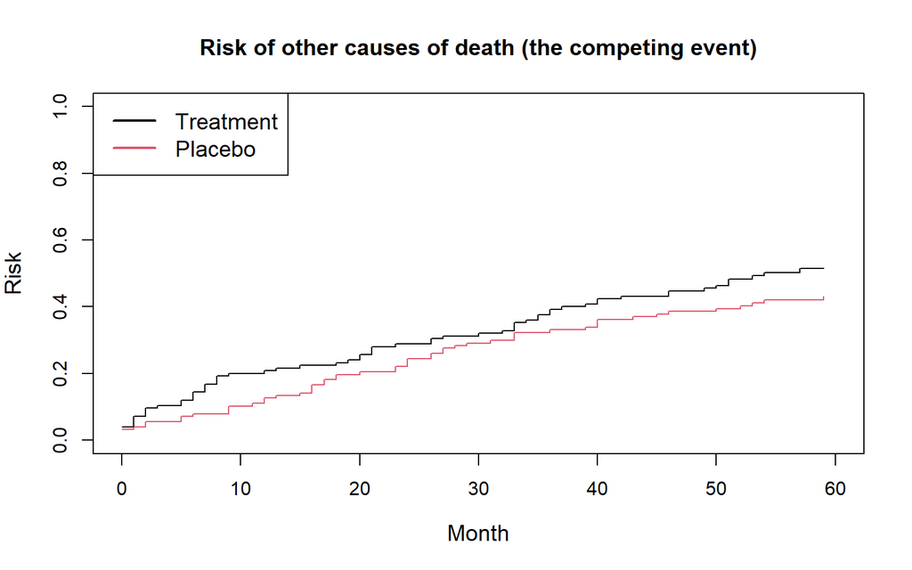

```r
plot(
  cutTimes,
  cumIncTreated_te_comp, type = "s",
  ylim = c(0, 1), ylab = "Risk", xlab = "Month",
  lty = 1, lwd = 1, xlim = c(0, 60),
  cex.lab = 1.2, cex.main = 1.2,
  main = c(
    paste("Risk of other causes of death (the competing event)")
  ))

lines(
  cutTimes,
  cumIncPlacebo_te_comp,
  type = "s", col = 2, ylim = c(0, 1), lwd = 1)

legend(
  "topleft", c("Treatment", "Placebo"),
  col = c(1, 2, 1, 2), lty = c(1, 1, 2, 2),
  cex = 1.2, pt.cex = 1.2, lwd = 2)
```

## Separable effects

Following equation (11) from [Stensrud et al. Journal of the American Statistical Association. 2020](https://www.tandfonline.com/doi/full/10.1080/01621459.2020.1765783)

To this matter, we will use the long format data set prepared before: `longProstRed`.

- Make one extra copy of the exposure `rx`, named `Orx`, to be used in the hazard of death due to other causes.

```r
longProstRed$Orx <- longProstRed$rx
```

- Fit conditional pooled logistic regression models

```r
plrFitP <-
    glm(
      prostateDeath ~ rx*(dtime + I(dtime ^ 2)+ I(dtime ^ 3)) + normalAct + ageCat + hx + hgBinary,
      data = longProstRed,
      family = binomial()
    )

plrFitO <-
  glm(
    otherDeath ~ Orx * (dtime + I(dtime ^ 2) + I(dtime ^ 3)) + normalAct + ageCat + hx + hgBinary,
    data = longProstRed,
    family = binomial()
  )
```

- Create three copies of the data. Data set construction where Ay and Ad = 1

```r
treated <-
    baseline[rep(1:n, each = length(cutTimes)), ] #One row for each time

treated$dtime <- rep(cutTimes, n)

treated$rx <- 1

treated$Orx <- 1
```

- Data set construction where Ay and Ad = 0

```r
placebo <-
    baseline[rep(1:n, each = length(cutTimes)), ] #One row for each time

placebo$dtime <- rep(cutTimes, n)

placebo$rx <- 0

placebo$Orx <- 0
```

- Dataset construction where Ay = 1, Ad = 0

```r
treatAy <-
    baseline[rep(1:n, each = length(cutTimes)), ]

treatAy$dtime <- rep(cutTimes, n)

treatAy$rx <- 1

treatAy$Orx <- 0
```

- Calculate hazards for each time interval in the three cloned data sets

```r
## For Ay = 1 and Ad = 1

treated$hazardP <-
    predict(plrFitP, newdata = treated, type = 'response')

treated$hazardO <-
    predict(plrFitO, newdata = treated, type = 'response')

treated$s <- (1 - treated$hazardP) * (1 - treated$hazardO)

## For Ay = 0, Ad = 0

placebo$hazardP <-
    predict(plrFitP, newdata = placebo, type = 'response')

placebo$hazardO <-
    predict(plrFitO, newdata = placebo, type = 'response')

placebo$s <- (1 - placebo$hazardP) * (1 - placebo$hazardO)

## For Ay = 1, Ad = 0

treatAy$hazardP <-
    predict(plrFitP, newdata = treatAy, type = 'response')

treatAy$hazardO <-
    predict(plrFitO, newdata = treatAy, type = 'response')

treatAy$s <- (1 - treatAy$hazardP) * (1 - treatAy$hazardO)
```

- Calculate weights for censoring for lost to follow-up

```r
plrFitC <-
  glm(
    eventCens ~ Orx* (dtime + I(dtime ^ 2) + I(dtime ^ 3)) + normalAct + ageCat +
      hx + hgBinary,
    data = longProstRed,
    family = binomial()
  )

predC <- 1 - predict(plrFitC, newdata = longProstRed, type = 'response')

# Create a new data frame with predicted hazard estimates from treated and
weightFrame <-
  data.frame(
    dtime = treated$dtime,
    patno = treated$patno,
    predOa1 = (1 - placebo$hazardO),
    predOa0 = (1 - treated$hazardO)
  )

compWeightsO <-
  merge(longProstRed,
        weightFrame,
        by = c('patno', 'dtime'),
        all.x = TRUE, sort = FALSE)

predOa0 <- compWeightsO$predOa0

predOa1 <- compWeightsO$predOa1

cum_pred_O_0 <-
  unlist(aggregate(predOa0 ~ compWeightsO$patno, FUN = cumprod)$predOa0,
         use.names = F) #unlist because aggregate creates list

cum_pred_O_1 <-
  unlist(aggregate(predOa1 ~ compWeightsO$patno, FUN = cumprod)$predOa1,
         use.names = F) #unlist because aggregate creates list

cum_pred_C <-
  unlist(aggregate(predC ~ compWeightsO$patno, FUN = cumprod)$predC,
         use.names = F) #unlist because aggregate creates list

ipw_d <- rep(NA, length.out = length(cum_pred_C))

# index time zeros

t0 <- longProstRed$prostateDeath == 0

ipw_d <- cum_pred_O_1 / cum_pred_O_0

ipw_d <- cum_pred_O_1 / cum_pred_O_0

ipw_cens <- 1 / cum_pred_C

ipw_sep_eff <- ipw_d / cum_pred_C
```

Last, we will use the function `discrete_cuminc_prost`, from the `utility_functions` script available in this repository.

```r
discrete_cuminc_prost <- function(weight_vector, inputdata, grp=0, outcome_y=TRUE,follow_up=1:max_time){
  event_vec <- rep(NA, length.out=length(follow_up))
  counter <- 1
  # count number of individuals in grp (that is, we cound those who were present at baseline)
  n_grp <- sum(inputdata$dtime==0 & inputdata$rx==grp)
  for(i in follow_up){
    if(outcome_y){
      indices <- inputdata$dtime==i & inputdata$rx == grp & inputdata$eventCens==0 & inputdata$otherDeath==0
      eventIndicator <- indices & inputdata$prostateDeath==1
    }else{
      indices <- inputdata$dtime==i & inputdata$rx == grp & inputdata$eventCens==0
      eventIndicator <- indices &  inputdata$otherDeath==1
    }
    event_vec[counter] <- sum(weight_vector[eventIndicator]) / n_grp
    counter <- counter+1
  }
  output_cuminc <- cumsum(event_vec)
  return(output_cuminc)
}
```

```r
cumIncTreatAyIPW <-
  discrete_cuminc_prost(ipw_sep_eff, longProstRed, grp = 1, follow_up = cutTimes)

cumIncTreatedIPW <-
  discrete_cuminc_prost(ipw_cens, longProstRed, grp = 1, follow_up = cutTimes)

cumIncPlaceboIPW <-
  discrete_cuminc_prost(ipw_cens, longProstRed, grp = 0, follow_up = cutTimes)


estimatesFullData <-
  data.frame(cumIncTreatedIPW, cumIncTreatAyIPW, cumIncPlaceboIPW)

knitr::kable(round(estimatesFullData[36,], 2))
```

|  | cumIncTreatedIPW | cumIncTreatAyIPW | cumIncPlaceboIPW |
| --- | --- | --- | --- |
| 36 | 0.14 | 0.15 | 0.2 |

- Cumulative incidence curves

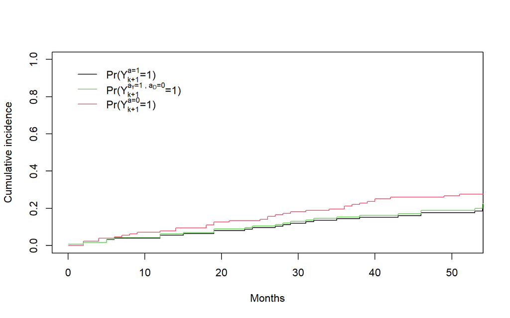

```r
plot(cutTimes,cumIncTreatedIPW, type="s",ylim=c(0,1), ylab="Cumulative incidence",
     xlab="Months",lty=1,lwd=1,xlim=c(0,52))
lines(cutTimes,cumIncPlaceboIPW, type="s",col=2,ylim=c(0,1),lwd=1,lty=1)
lines(cutTimes,cumIncTreatAyIPW, type="s",col=3,ylim=c(0,1),lwd=1,lty=1)
legend(x=0,y=1, c(expression('Pr('*'Y'['k+1']^{"a"*'=1'} *'=1' * ')' ),expression('Pr('*'Y'['k+1']^{"a"['Y']*'=1' * ' , ' * "a"['D']*'=0'} *'=1' * ')' ),expression('Pr('*'Y'['k+1']^{"a"*'=0'} *'=1' * ')' )),bty = "n",
       col=c(1,3,2), lty=c(1,1,1),cex=1,pt.cex=1,lwd=1)
```

### [Go to: Data cleaning and setup here](https://palolili23.github.io/SER_competing_events_workshop/R/index.html)

### [Go to: Direct, total and separable effects, using G-formula](https://palolili23.github.io/SER_competing_events_workshop//R/gform.html)

### [Go to github repository](https://github.com/palolili23/SER_competing_events_workshop/)

# References

- Young JG, Stensrud MJ, Tchetgen Tchetgen EJ, Hernán MA. A causal framework for classical statistical estimands in failure time settings with competing events. Statistics in Medicine 2020. [Paper link](https://onlinelibrary.wiley.com/doi/abs/10.1002/sim.8471) [Code](https://github.com/CausalInference/CompetingEvents_Young_SIM_2020)
- Stensrud MJ, Young JG, Didelez V, Robins JM, Hernán MA. Separable Effects for Causal Inference in the Presence of Competing Events. Journal of the American Statistical Association 2022. [Paper link](https://www.tandfonline.com/doi/full/10.1080/01621459.2020.1765783)
- Rojas-Saunero LP, Young JG, Didelez V, Ikram MA, Swanson SA. Considering questions before methods in dementia research with competing events and causal goals. American Journal of Epidemiology. 2023. [Paper link](https://academic.oup.com/aje/advance-article/doi/10.1093/aje/kwad090/7120022) [Code](https://github.com/palolili23/competing_risks_dementia)